# 발표자

국내외 데이터 과학 R/Tidyverse 발전에 기여 및 비젼을 제시해주신 분들이 함께 지식과 경험을 나누는 자리입니다

# 키노트 발표

[쥴리아 실기(Julia Silge)](https://juliasilge.com/)

유충현

[figure not shown]

Julia Silge is a data scientist and software engineer at RStudio PBC where she works on open source modeling tools. She is an author, an international keynote speaker, and a real-world practitioner focusing on data analysis and machine learning practice. Julia loves text analysis, making beautiful charts, and communicating about technical topics with diverse audiences.

Korea R User Group 창설을 주도하셨고 초대 대표 역임하셨으며 2011년, 2012년 1회/2회 Korea R User Conference를 이끄셨고, [“R을 이용한 통계학의 이해”](http://www.yes24.com/Product/Goods/8920562) 외 5종 저술을 통해 한글 R/Tidyverse 대중화에 크게 기여를 하셨으며, CRAN에 R 팩키지 [`dlookr`](https://cran.r-project.org/web/packages/dlookr/index.html), [`alookr`](https://cran.r-project.org/web/packages/alookr/index.html) 를 기여하였다. 현재는 [Seoul R Meetup](https://tidyverse-korea.github.io/seoul-R/), [Tidyverse Korea](https://www.facebook.com/groups/tidyverse) 운영위원으로 R/Tidyverse 보급과 선진화에 헌신적인 기여를 하고 있다.

### Creating features for machine learning from text

Natural language that we as speakers and writers use must be dramatically transformed to new representations for analysis, whether we are just starting off with exploratory data analysis or are ready to train machine learning algorithms such as predictive models. We can explore typical text preprocessing steps from the ground up, from tokenization to building word embeddings, and consider the effects of these steps. When are these preprocessing steps helpful, and when are they not? In this talk, learn about the process of text preprocessing for ML models in the real world, how and when practitioners use different preprocessing choices, and considerations for text ML tooling.

### **Again wind in Korea with GNU R**

아카데미 영역에서 R을 이용한 데이터 분석 교육 방안과 엔터프라이즈 영역에서 R을 이용하여 데이터 분석 업무를 효율적으로 수행하는 방법 제시

.

.

.

.

.

.

.

.

# 프로그램 발표

**☀ 한국 R 컨퍼런스 발표자 ☀**

*오픈 커뮤니티, 스타트업, 국내외 대학, 병원, 산업계*

발표자명

소속

발표자소개

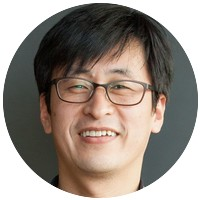

이광춘

R사용자회

인공지능, 데이터과학, 클라우드 등과 거리가 있어 보이는 FTA 원산지관리 및 차량용 반도체 개발구매를 10여년 경험한 후에 전국민 오픈 소프트웨어 교육을 위해 xwMOOC 프로젝트를 진행한 후에 현재는 데이터 과학자로 오픈 통계 팩키지를 R 사용자회 개발자분들과 함께 개발하고 있다. 전국민 오픈 통계/소프트웨어/컴퓨터 교육을 위해 xwMOOC 프로젝트로 지금까지 10여권의 책을 번역 직접 저작해서 지식과 경험을 공유하고 있다. CS Unplugged (컴퓨터 과학 언플러그드) 3.1 버전, 리보그/러플(Rur-Ple) 파이썬 배우기: 러플로 아이들이 놀기!, 소프트웨어 카펜트리, 정보교육을 위한 파이썬, R 팩키지, 통계적 사고하기, R 데이터 과학, 라즈베리 파이 등.

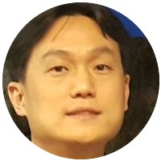

최재성

성균관대

경제학(노동경제학, 프로그램 평가 방법론)을 전공하였으며, 현재 성균관대학교 경제대학에서 실증 분석에 초점을 맞춘 다양한 강의와 연구를 수행하고 있다. 교육 정책, 불평등, 그리고 노동시장과 관련된 이슈를 주된 연구 대상으로 하고 있다. 아울러 R을 사용해서 웹에서 다양한 정보를 수집해서 데이터를 구축하고 이를 사회과학 연구에 활용하려고 노력하고 있다. 동료 사회과학 연구자들과 (직장인) 학생들이 연구뿐만 아니라 일상 생활과 현업에서도 폭넓게 프로그래밍을 활용할 수 있기를 바라며 업무 자동화와 시각화 관련 콘텐츠를 개발하는 작업에도 관심을 기울이고 있다.

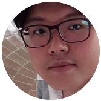

박상훈

University of South Carolina

미국 사우스캐롤라이나 주립대학교 정치학과에서 비교정치를 전공하고 있다. 주로 권위주의 국가들을 대상으로 독재자들과 제도 간의 상호작용을 자원의 분배, 체제의 안정성, 그리고 체제 전환에 관해 연구하고 있다. 데이터가 상대적으로 불확실성을 가지는 권위주의 국가를 분석함에 있어서 시뮬레이션 접근을 적용하기 용이한 R에 관심을 가지게 되었다. R이라는 범용성을 가진 도구를 통해 기존의 정치학 분야에서 다루어왔던 여러 주제들 뿐 아니라, 새로운 연구문제들에 보다 자유롭게 접근할 수 있을 것이라고 기대한다.

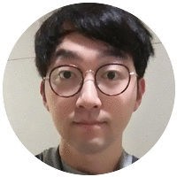

이민호/김상현

데이터라이즈

(이민호) 데이터 분석가로 커리어를 시작했지만, 지금은 고객들이 데이터를 쉽게 사용할 수 있도록 돕는 프로덕트를 만들고 있습니다. 이커머스를 위한 올인원 그로스 솔루션을 만드는 스타트업 데이터라이즈의 프로덕트 오너입니다. / (김상현) R을 즐겨 사용하는 주니어 데이터 분석가입니다. 데이터 분석과 모델링을 통해, 이커머스를 성장시킬 수 있는 다양한 전략을 고민합니다. R을 이용한 분석과 모델링 결과물들을 프로덕션 수준으로 구축하기 위해 고군분투하고 있습니다.

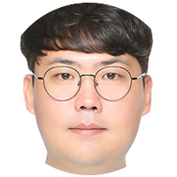

이준혁

Seegene

통계학을 전공하였으며, 다양한 산업에서 데이터 분석 경험을 쌓고 있는 분석가입니다. 현재는 데이터의 Full Stack을 위해 달리고 있으며, 데이터를 통한 가치를 창출하기 위해 많은 노력을 하고 있는 잡부입니다.

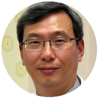

문건웅

가톨릭의대

가톨릭대학교 의과대학 순환기내과 교수이다. 1990년에 가톨릭대학교 의과대학을 졸업한 후 줄곧 대학병원에 근무하면서 협심증, 심근경색과 같은 관상동맥질환자의 중재시술을 담당하고 있고, 현재 가톨릭대학교 부속 성빈센트병원 순환기내과 과장으로 재직 중이다. 2001년 정보처리기사 1급 자격증을 취득하였고, 2014년에는 Coursera(www.coursera.org)를 통해 Johns Hopkins 대학의 Data Science라는 제목의 Specialization course 9개 과목을 모두 수료하였다. 최근에는 mycor, moonBook, ztable 등 3개의 R 패키지를 개발하여 CRAN(CRAN.r-project.org)을 통하여 배포하고 있다. 최근 출간된 저서《의학논문 작성을 위한 R 통계와 그래프》는 2015년 대한민국학술원 우수학술도서로 선정되었으며, ‘웹에서 하는 R통계’서버(Web-R.org)를 직접 운영하고 있다.

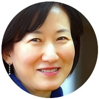

이혜선

POSTECH

전공은 통계학(데이터과학, 고차원데이터)이며, 데이터 애널리스트로서 고객만족지수(한국생산성본부), 고객구매예측(삼성전자), 신약임상분석(pfizer)과제를 수행했고, MOOC강좌로 KMOOC에서 [데이터과학을 위한 R프로그래밍], [청년/AI아카데미과정](https://pabi.smartlearn.io/), 기업MOOC를 열고 있다.

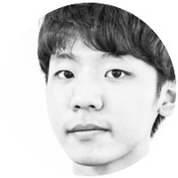

이남신

오피지지

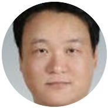

박성우

베가스

전산학을 전공하였으며,CRM/모바일/IT Business Development 및 컨설팅업무를 진행하다 데이터분석 전문 회사인 (주)베가스에 합류하여 자본시장예측, IoT 기반 이상탐지 및 고장예측 등 분석리더 역할을 수행 하였으며, 데이터산업의 중심인 데이터와 데이터분석 업무를 생태계 이해관계자가 쉽고, 효율적으로 협업할 수 있는 데이터분석 방법론 및 가이던스를 체계화 하고 있으며, 또한 이를 데이터과학자 도구와 접목,데이터분석업무의 셀프-서비스화를 진행 데이터분석업무의 확산을 꾀하고 있습니다.

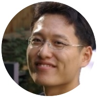

이영록

The Walt Disney Company

산업공학을 전공하였으며, 여러 데이터마이닝 기법들을 연구 및 현업에 활용하여 왔다. 데이터 처리, 시각화, 모델링, 문서화, 사용자 인터페이스 구현 등 데이터 분석 전반에 걸쳐 R을 사용하여 왔으며, 최근에는 데이터 분석 방법 교육 및 데이터 분석 생산성 향상에 대해 관심을 기울이고 있다.

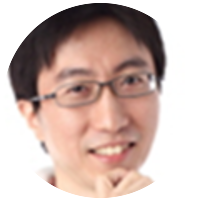

이은조

NCSoft

게임을 직접 하는 것보다 다른 사람의 게임 플레이 데이터를 분석하는게 더 재미있습니다. 온라인 게임 속 세계는 현실 세계만큼이나 극적이고 다양한 것 같습니다. 벌써 회사에 들어온지 10년이 넘었지만 그런 게임 속 세계를 온전히 이해하고 싶어 고인물처럼 버티고 있습니다.

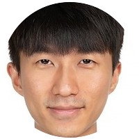

황의찬

명지대학교

경제학을 전공하였으며 세법 및 재정분야 빅데이터 분석에 관심을 기울이고 있다.

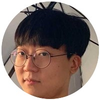

김진환

Code States

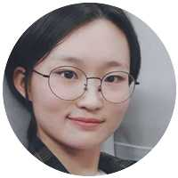

윤화영 외

Tidyverse Korea

Data Literacy 역량 강화를 위해 컴퓨터를 처음 접하거나 데이터 작업이 처음인 대한민국 국민 누구나 쉽게 통계 패키지를 접할 수 있도록 하고 데이터 프로그래밍 역량도 수준별로 강화할 수 있도록 새로운 형태의 블록 통계 분석을 포함한 초중등 오픈 통계 패키지 개발을 목표로 2021년 오픈소스 컨트리뷰션 아카데미 Tidyverse 데이터 과학 커뮤니티로 함께 했습니다.

**R 사용자회**: 상기 발표내용은 사정에 따라 변경될 수 있습니다.